# Dados do estudo de caso AMAZON

Luiz C. E. Rodriguez, Eric B. Gorgens, Humberto T. Menecheli Filho, Nathan O. Barreto

2022-10-29

# Floresta*R*

O projeto **Floresta*R*** reúne professores, estudantes e profissionais dedicados à redação da série **Floresta*R*** de livros sobre o uso do *R* como ferramenta de análise de dados florestais.

# Sobre os autores

Os autores da série de livros **Floresta*R*** são:

- **Luiz Carlos Estraviz Rodriguez**, professor titular da Escola Superior de Agricultura Luiz de Queiroz (ESALQ) da Universidade de São Paulo
- **Eric Bastos Gorgens**, professor do Departamento de Engenharia Florestal da Universidade Federal dos Vales do Jequitinhonha e Mucuri (UFVJM)
- **Humberto Tadeu Menecheli Filho**, engenheiro florestal analista de dados da ForLiDAR
- **Nathan de Oiveira Barreto**, graduando de engenharia florestal da ESALQ/USP

# Sobre os livros

A coleção está em constante evolução, e no momento é constituida pelos seguintes volumes:

- **Vol_01** Análise exploratória de dados florestais
- **Vol_02** Inferência estatística com dados florestais
- **Vol_03** Amostragem para fins de inventário florestal
- **Vol_04** Processamento de dados LiDAR para monitoramento florestal

# Conjuntos de dados

Os dados dos estudos de caso usados nos exercícios da série de livros **Floresta*R*** estão organizados em pastas:

| Pasta | Conteúdo |
| --- | --- |
| 1_AMAZON | Árvores inventariadas na Amazônia |
| 2_RESTAU | Medições de árvores de espécies nativas coletadas em área de restauração de corredor ecológico |
| 3_VOLIND | Árvores de *Eucalytus* cubadas para modelagem de volume individual |
| 4_INVENT | Medições de árvores de *Eucalyptus* em parcelas de inventário convencional |
| 5_LIDARF | Nuvens de pontos LiDAR sobre plantio florestal para mapeamento de biomassa |

# Dados do estudo de caso AMAZON

A pasta `AMAZON` contém as medições de árvores inventariadas em 2010 para fins de manejo florestal. Implantado às margens da BR 364, no município de Porto Velho (RO) em área próxima à divisa com o Acre, o plano se refere à UPA 4 (Unidade de Produção Anual número 4). Todas árvores (*censo 100%*) com mais de 40cm de diâmetro à altura do peito (DAP) nessa área foram identificadas, geolocalizadas, medidas e destinadas para compor um dos seguintes grupos:

| Código | Destinação |
| --- | --- |
| APP | Em área de preservação permanente |
| CF | Corte futuro (árvore com DAP entre 40 e 50 cm) |
| CPL | Corte protegido por lei |
| PAB | Para abate |
| PS | Porta semente |
| RAR | Rara |
| REM | Remanescente |

O acesso aos dados deste repositório é mantido aberto para maximizar acessibilidade e permitir a reprodutibilidade dos exemplos publicados nos livros da série **Floresta*R***. Os dados foram estruturados em tabelas [tidy](https://r4ds.had.co.nz/tidy-data.html) e [shape](https://www.esri.com/content/dam/esrisites/sitecore-archive/Files/Pdfs/library/whitepapers/pdfs/shapefile.pdf) para facilitar o uso das funções **tidyverse** e **sf** do *R*.

As medições na UPA4 geraram dados sobre 20.108 árvores. Esses dados foram armazenados em planilhas `CSV` e `XLSX`, e na tabela de atributos de um `shape` de pontos georeferenciados que identifica a precisa localização dessas árvores.

### . Formato `CSV`

O conteúdo da planilha `Censo_UPA04.csv` pode ser importado para uma *tibble* `dados`, da seguinte forma:

```r
library(tidyverse)
gitOnde <- "https://github.com/FlorestaR/dados/blob/main/1_AMAZON"
gitNome <- "Censo_UPA04.csv"
gitArqv <- file.path(gitOnde, gitNome) %>% paste0("?raw=true")

dados <- read_csv(gitArqv,                     # importação
         locale = locale(encoding = "latin1"), # garante acentuação
         show_col_types = FALSE) %>% tibble()  # desabilita msgs

dados$dia <- dados$dia %>% as.Date("%d/%m/%Y") # garante formato date
```

`gitOnde` define a pasta dentro do repositório, `gitNome` define o arquivo de dados e `gitArqv` concatena esses dois termos com o sufixo `?raw=true` para criar o devido URL. Em seguida o URL é passado para a função `read_csv()` do pacote **readr** do **tidyverse**.

A função `read_csv()` do pacote **readr** permite que um usuário R conectado à internet leia diretamente os dados mantidos em repositórios [github](https://github.com).

### . Formato `XLSX`

Para ler a versão `xlsx` dos mesmos dados, uma alternativa é usar a função `import()` do pacote **rio**:

```r
library(tidyverse)
gitOnde <- "https://github.com/FlorestaR/dados/blob/main/1_AMAZON"
gitNome <- "Censo_UPA04.xlsx"
gitArqv <- file.path(gitOnde, gitNome) %>% paste0("?raw=true")

library(rio)

dados <- import(file = gitArqv) %>% tibble() # importação
dados$dia <- dados$dia %>% as.Date()         # garante formato date
```

Nesse caso, a acentuação nos caracteres especiais já é importada corretamente, havendo necessidade apenas de garantir que a coluna `dia` registre os valores como `date`.

### . A *tibble* `dados`

A função `str()` nos permite ver detalhes da estrutura da *tibble* `dados`:

```r
str(dados)
```

```
## tibble [20,108 × 17] (S3: tbl_df/tbl/data.frame)
##  $ codARV  : num [1:20108] 40100001 40100002 40100003 40100004 40100005 ...
##  $ codUT   : num [1:20108] 1 1 1 1 1 1 1 1 1 1 ...
##  $ codUCA  : num [1:20108] 1 1 1 1 1 1 1 1 1 1 ...
##  $ codLIN  : num [1:20108] 1 1 1 1 1 1 1 1 1 1 ...
##  $ X       : num [1:20108] 5 23 43 47 40 14 37 22 15 31 ...
##  $ Y       : num [1:20108] 13 11 4 7 12 21 25 25 40 36 ...
##  $ dia     : Date[1:20108], format: "2010-03-03" "2010-03-03" ...
##  $ nome    : chr [1:20108] "taxi" "caucho" "ucuuba" "pamã" ...
##  $ sp      : chr [1:20108] "Sclerolobium paniculatum" "Castilla ulei" "Virola surinamensis" "Pseudolmedia laevis" ...
##  $ dap     : num [1:20108] 70.8 50.1 43.5 52.8 41.1 46.1 50.2 91.7 57 73 ...
##  $ altura  : num [1:20108] 15 12 17 10 15 12 15 18 10 12 ...
##  $ notaFUST: num [1:20108] 1 2 1 1 2 1 1 1 2 2 ...
##  $ notaCIPO: num [1:20108] 1 2 2 2 1 2 2 2 1 2 ...
##  $ clasDAP : chr [1:20108] "070-080" "050-060" "040-050" "050-060" ...
##  $ areaBAS : num [1:20108] 1.575 0.789 0.594 0.876 0.531 ...
##  $ volume  : num [1:20108] 4.13 1.66 1.77 1.53 1.39 ...
##  $ destino : chr [1:20108] "REM" "PS" "CF" "RAR" ...
```

### . Formato *`shape`*

Os dados diponibilizados nos formatos `CSV` e `XLSX` se encontram também disponíveis na tabela de atributos do `shape` `Arvores`, com a localização geográfica de cada árvore. O *download* desse, e de outros `shapes` complementares, premite reproduzir os exercícios de exploração de dados espacializados.

Os exercícios com as árvores georeferenciadas usam funções do pacote **sf** do **R**. A função `read_sf()` desse pacote permite ler camadas vetoriais (*layers*) de informação SIG armazenadas no formato `shape`.

Para download dos `shapes` e leitura da tabela de árvores georeferenciadas, sugere-se o seguinte procedimento:

```r
library(tidyverse)

gitOnde <- "https://github.com/FlorestaR/dados/blob/main/1_AMAZON/"
gitNome <- "shapes.zip"
gitArqv <- file.path(gitOnde, gitNome) %>% paste0("?raw=true")

tmpd <- tempdir(check = TRUE)                  # diretório temporário
zipf <- file.path(tmpd, "shapes.zip")            # arquivo temporário

if(!file.exists(zipf))  # garante download de dados binários (wb)
  download.file(gitArqv, mode="wb", destfile = zipf)

unzip(zipf, exdir = tmpd)   # shape é unziped no diretório temporário
unlink(zipf)                                # deleta o arquivo zipado

library(sf)

shpArq <- paste0(tmpd, "/shapes/Arvores.shp")     # shape com árvores
dadosComGeo <- sf::read_sf(shpArq)             # df completo com geom
dadosSemGeo <- tibble(st_drop_geometry(dadosComGeo))    # df sem geom

dadosSemGeo %>%                       # Cinco castanheiras mais altas
  filter(nome=="castanheira") %>%
  select(codARV,sp,codUT,codUCA,dap,altura) %>%
  arrange(desc(altura)) %>%
  head(5) %>%
  knitr::kable(caption = "Lista das 5 maiores castanheiras")
```

Lista das 5 maiores castanheiras

| codARV | sp | codUT | codUCA | dap | altura |
| --- | --- | --- | --- | --- | --- |
| 40401295 | Bertholetia excelsa | 4 | 6 | 165.6 | 30 |
| 40501461 | Bertholetia excelsa | 5 | 7 | 71.6 | 30 |
| 40501504 | Bertholetia excelsa | 5 | 15 | 92.0 | 30 |
| 40501700 | Bertholetia excelsa | 5 | 12 | 90.6 | 30 |
| 40300157 | Bertholetia excelsa | 3 | 13 | 132.2 | 29 |

Para ilustrar a vantagem de usar a versão georeferenciada de `dados`, apresenta-se um exemplo que exibe uma sobreposição das camadas `APP` e `UTs` com as `castanheiras`.

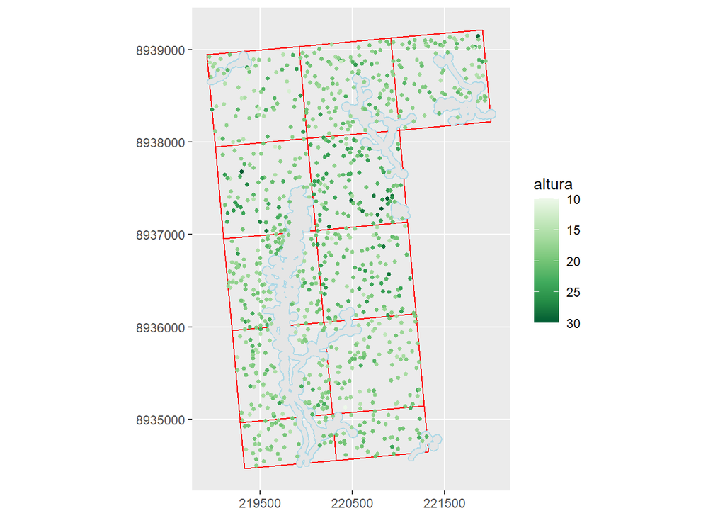

```r
library(tidyverse)

gitOnde <- "https://github.com/FlorestaR/dados/blob/main/1_AMAZON"
gitNome <- "shapes.zip"
gitArqv <- file.path(gitOnde, gitNome) %>% paste0("?raw=true")

tmpd <- tempdir(check = TRUE)                  # diretório temporário
zipf <- file.path(tmpd, "shapes.zip")            # arquivo temporário

if(!file.exists(zipf))      # garante download de dados binários (wb)
  download.file(gitArqv, mode="wb", destfile = zipf)

unzip(zipf, exdir = tmpd)   # shape é unziped no diretório temporário
unlink(zipf)                                # deleta o arquivo zipado

library(sf)

# leitura das camadas
dadosArv <- paste0(tmpd, "/shapes/Arvores.shp")     %>% read_sf()
dadosUca <- paste0(tmpd, "/shapes/UCAs.shp")        %>% read_sf()
dadosUts <- paste0(tmpd, "/shapes/UTs.shp")         %>% read_sf()
dadosApp <- paste0(tmpd, "/shapes/APP.shp")         %>% read_sf()
dadosHid <- paste0(tmpd, "/shapes/Hidrografia.shp") %>% read_sf()
dadosEst <- paste0(tmpd, "/shapes/Estrada.shp")     %>% read_sf()
dadosRam <- paste0(tmpd, "/shapes/Ramal.shp")       %>% read_sf()
dadosPat <- paste0(tmpd, "/shapes/Patios.shp")      %>% read_sf()

Especie <- dadosArv %>%                # novo df só com castanheiras
  filter(nome=="castanheira") %>%
  select(codARV,altura,dap,volume)

ggplot() +      # plot das UTs, APPs e castanheiras (col por altura)
  geom_sf(data = dadosUts, colour = "red", fill=NA) +
  geom_sf(data = dadosApp, colour = "lightblue") +
  geom_sf(data = Especie, aes(colour = altura), size = 1) +
  scale_color_distiller(palette = "Greens", trans = "reverse") +
  coord_sf(datum=st_crs(29190)) +     # Especifica sistema de coord.
  scale_x_continuous(breaks = seq(from = 218500, to = 223000, by = 1000))
```

Caso encontre alguma inconsistência nas informações deste repositório, ou queira registrar um comentário, clique em [`issues`](https://github.com/LuizEstraviz/FlorestaR_dados/issues) no menu do repositório github.com/LuizEstraviz/FlorestaR_dados e deixe a sua contribuição clicando no botão `New issue`. Agradecemos o seu interesse por esta iniciativa.

Disclaimer: Os dados são disponibilizados para fins exclusivamente educativos e não devem ser usados para outro propósito. O uso fora do contexto para o qual estão sendo disponibilizados, mesmo que apenas parcialmente, além de indevido, produzirá resultados impróprios, pois alguns dos atributos originais desses dados foram propositalmente modificados para simplificar a realidade. Os autores não se responsabilizam pelo uso indevido que, além de infringir códigos científicos e éticos de conduta, extrapole o caráter ilustrativo dos exercícios que apresentamos na série de livros **Floresta*R***.